# Recommender System

Anthony A

9/19/2022

# Abstract

A recommender system is intended to predict the sentiment of users based on the collective population. In the movie streaming services such as Amazon, we can generate user recommendations for movies. The idea is that watchers conform to a niche so they will continue to watch and rate those movies highly. By finding out what half of the group liked to watch, we can predict that the other half will also be interested. Thus, when collective users of the same niche exist, these groups of data observations are called clusters.

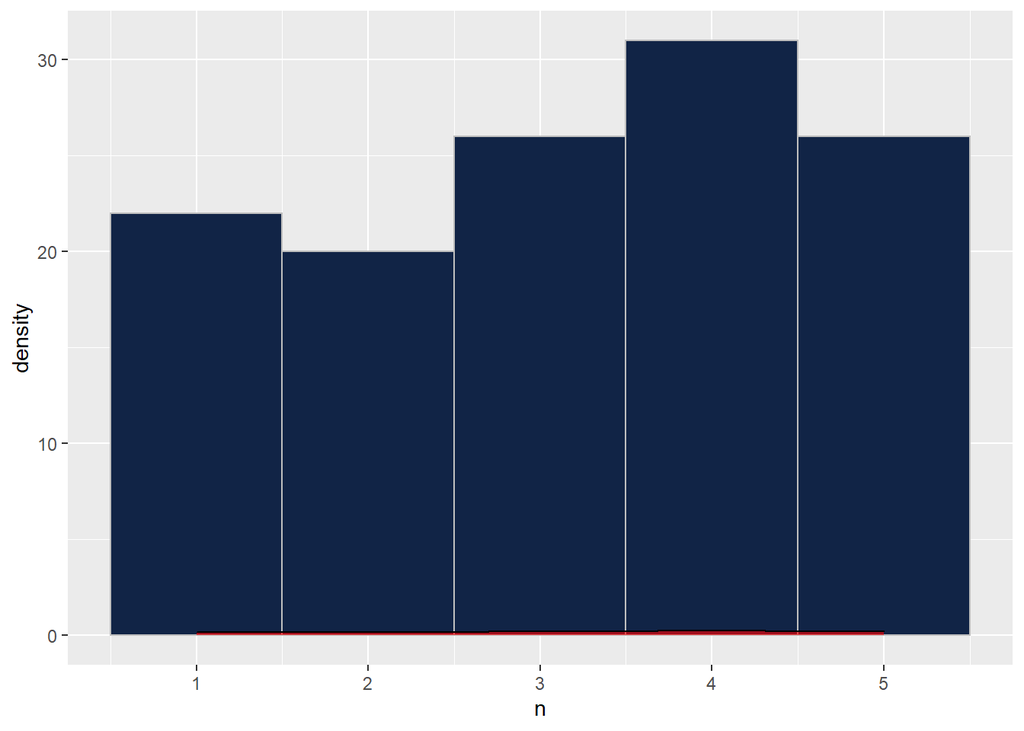

```r
### Shortens column names for printing
ShortenTitles <- function(df, n = 12) {
  magrittr::set_colnames(df, substring(colnames(df), 1, n))
}

### Generates an n-length vector of integers 1 through 5
generatedVector = set.seed(8675309) %>%
  { rnorm(240, 3, 2) } %>%
    { . %% 5 } %>%
      ceiling(.) %>%
        { (function(x) {
          deleteVals = runif(length(x)) > 0.5
          x[deleteVals] = NA
          return(x)
        })(.) }

### Visualizes the distribution of randomized data in a histogram
generatedVector %>%
  .[! is.na(.)] %>%
    data.frame(n = .) %>%
      ggplot2::ggplot(.) +
      ggplot2::aes(x = n) +
      ggplot2::geom_histogram(bins = 5L, fill = "#112446", col="grey") +
      ggplot2::geom_density(alpha = 0.6, fill = "red")
```

# Datasets

Data generation is used in lieu of actual data. The data has to be pruned of empty rows or else there is no baseline to estimate the customer’s desires. As a result, a recommender system has to recommend the top 10 movies of all time for a brand new customer.

```r
### Top ten movies of 1963
movieTitles = c(
  "Cleopatra", "How the West Was Won", "It's a Mad, Mad, Mad, Mad World",
  "Tom Jones", "Irma la Douce", "Son of Flubber", "Charade", "Bye Bye Birdie",
  "Come Blow Your Horn", "Move Over, Darling", "The Great Escape"
)

### Converts generated data into a matrix and removes empty rows
data = as.data.frame(matrix(generatedVector, ncol = 6)) %>%
  magrittr::set_colnames(., movieTitles[1:ncol(.)]) %>%
    .[apply(., 1, function(x) { any(! is.na(x))}), ]

### Check data for cleanliness on a pre-written capacity
testthat::test_that("All rows have at least one value", {
  testthat::expect_true(all(apply(data, 1, function(x) {
    any(! is.na(x))
  })))
})
```

```
## Test passed
```

# Global Baselines

```r
### Calculates the mean of each row and column
userBaselines = apply(data, 1, mean, na.rm = TRUE)
movieBaselines = apply(data, 2, mean, na.rm = TRUE)

### Calculates the mean of every available operation
avgMovieRating = mean(unlist(data), na.rm = TRUE)


movieBaselines
```

```
##                       Cleopatra            How the West Was Won
##                        3.217391                        2.809524
## It's a Mad, Mad, Mad, Mad World                       Tom Jones
##                        3.125000                        3.266667
##                   Irma la Douce                  Son of Flubber
##                        3.550000                        3.000000
```

# Known observations

The input data shown below is a glimpse of what data is available to our recommender system. Each row is a unique watcher. These are the ratings given by users who have already watched the movies.

```r
### Show the input data
head(ShortenTitles(data))
```

```
##   Cleopatra How the West It's a Mad,  Tom Jones Irma la Douc Son of Flubb
## 1        NA           NA           NA        NA           NA            3
## 2         5           NA            1        NA            5            4
## 3         2           NA           NA        NA            3            1
## 4        NA           NA           NA         1            3           NA
## 5         1           NA            5         4            3            5
## 6        NA           NA           NA        NA           NA            3
```

# Predicted ratings

```r
### Generates predictions from available data
artificialRatings = matrix(-avgMovieRating, nrow = length(userBaselines), ncol = length(movieBaselines)) %>%
  { . + movieBaselines } %>%
    t(.) %>%
      { . + userBaselines } %>%
        t(.)

### Show the created predictions
data.frame(artificialRatings) %>%
  magrittr::set_colnames(., movieTitles[1:ncol(.)]) %>%
    ShortenTitles(.) %>%
      format(., digits = 3) %>%
        head(.)
```

```
##   Cleopatra How the West It's a Mad,  Tom Jones Irma la Douc Son of Flubb
## 1     3.065        4.148         1.97     2.065        3.998        2.973
## 2     0.658        3.848         4.45     0.658        4.048        3.948
## 3     2.973        2.315         3.65     3.640        2.399        4.065
## 4     3.115        2.658         2.85     4.781        3.658        2.348
## 5     3.398        4.973         3.07     4.398        2.973        3.465
## 6     3.098        3.115         2.32     2.348        2.865        1.858
```

# Model Verification

It is important to verify that the predictions match the reality of the situation. By comparing the real data to the predicted values, we should run a statistical analysis. The mean and and median for this particular set makes it seem like it worked. However, the two extremes are +/- 4 which would be the exact *opposite* of the intended rating.

```r
### Generate data to see where historical data differs from predictions
confusionMatrix = data %>%
  { (function(df) {
    x = is.na(df)
    df[! x] = df[! x] - artificialRatings[! x]
    df
  })(.) }

### Get summary data to understand model accuracy
confusionMatrix[! is.na(confusionMatrix)] %>%
  unlist(.) %>%
    summary(.)
```

```
##     Min.  1st Qu.   Median     Mean  3rd Qu.     Max.
## -3.78133 -1.11467  0.02700  0.01313  1.34248  4.34248
```

This problem is even more apparent when the data is graphed. There is a bell shape because the randomly generated data is normally distributed. However, about half of the predictions are incorrect and too far away from zero. Hypothetically, a real dataset would exhibit clustering and be largely close to zero. Since the data is random with no favored clusters, the result is also random as shown below.

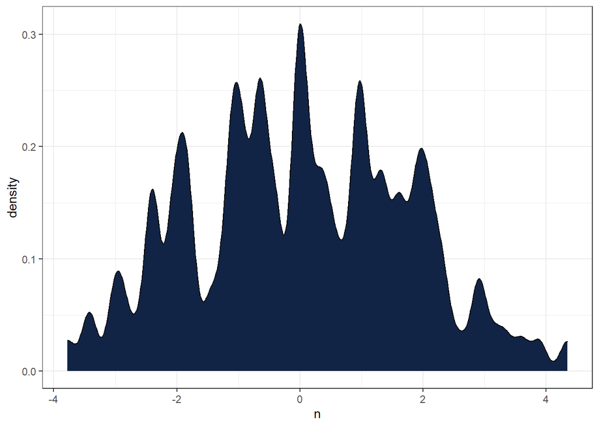

```r
### Generates a visualization of model accuracy
confusionMatrix %>%
  unlist(.) %>%
    .[! is.na(.)] %>%
      data.frame(n = .) %>%
        ggplot2::ggplot(.) +
        ggplot2::aes(x = n) +
        ggplot2::geom_density(adjust = 0.2, fill = "#112446") +
        ggplot2::theme_bw()
```